# ASSINGMENT_BOOSTING TECHNIQUES_PW SKILLS

#### 1. What is Boosting in Machine Learning? Explain how it improves weak

learners.

Boosting is an ensemble learning technique that creates a powerful, accurate predictive model by sequentially training weak learners, where each new model focuses on correcting the errors of the previous ones. It improves weak learners by assigning higher importance to misclassified data points from prior models, forcing subsequent learners to pay more attention to these challenging examples and ultimately building a strong model that is significantly more accurate than any individual weak learner. How Boosting Works 1. Sequential Training: Unlike methods like bagging that train models independently, boosting trains models one after another in a specific sequence. 2. Weighted Data: At each step, the algorithm adjusts the weights of the training data points. Data points that were misclassified by the previous model are given higher weights, and those correctly classified receive lower weights. 3. Focus on Mistakes: The next weak learner is then trained with the emphasis on the data points with the newly adjusted weights. 4. Iterative Refinement: This process is repeated for a set number of iterations or until a desired level of accuracy is reached. 5. Combining Predictions: Finally, the predictions from all the individual weak learners are combined, often through a weighted combination, to form the final, strong predictive model. How it Improves Weak Learners Bias Reduction: By iteratively correcting errors, boosting focuses on reducing the bias inherent in simple weak learners. Learning from Mistakes: Each weak learner learns from the mistakes of the model that came before it, allowing the combined model to become more sophisticated and accurate. Focus on Difficult Examples: Boosting's ability to assign higher weights to misclassified data points ensures that the model concentrates on the most challenging and informative parts of the data, improving its understanding of complex patterns. Creation of a Strong Learner: The cumulative effect of these sequential, error-correcting steps transforms a collection of simple, slightly better-than-random weak learners into a highly accurate and robust strong learner.

#### 2. What is the difference between AdaBoost and Gradient Boosting in terms

of how models are trained?

AdaBoost handles errors by re-weighting misclassified examples to focus subsequent learners on them, while Gradient Boosting addresses errors by fitting new models to the residual errors of the previous combined model using gradient descent, minimizing a specified loss function. AdaBoost increases the weight of difficult-to-classify samples, whereas Gradient Boosting aims to correct the "amount" of error by focusing on pseudo-residuals to refine the model's predictions. AdaBoost (Adaptive Boosting) Focus: AdaBoost gives more weight to data points that were misclassified by previous models. Mechanism: It uses a weighted vote from multiple simple weak learners (like decision stumps) to create a strong final classifier. Error Handling: After each round, the weights of misclassified examples are increased, making them more important for the next learner. Goal: To correctly classify the hard-to-classify examples that previous models struggled with. Gradient Boosting Focus: Gradient Boosting focuses on minimizing the overall loss function of the model by correcting the errors of the previous iteration. Mechanism: Each new base model (often a decision tree) is trained to predict the residual errors (the difference between the actual and predicted values) from the combined previous models. Error Handling: Instead of re-weighting samples, Gradient Boosting directly learns from the pseudo-residuals. Goal: To sequentially reduce the loss function's value through gradient descent to improve accuracy, making it flexible for both classification and regression. Key Differences in Training Handling Samples: AdaBoost directly adjusts the weights of samples. Gradient Boosting focuses on the errors of the entire model rather than individual sample weights. Error Correction: AdaBoost's correction is based on a binary "correct" or "incorrect" assessment. Gradient Boosting corrects the "how much" of the error through the gradient of the loss function. Model Complexity: AdaBoost typically uses very simple weak learners. Gradient Boosting can use more complex models, like decision trees, and is more flexible to different loss functions

#### 3. How does regularization help in XGBoost?

Regularization in XGBoost helps prevent overfitting and improves the generalization ability of the model by controlling its complexity. It achieves this by adding penalty terms to the objective function, which the algorithm tries to minimize during training. The key ways regularization helps in XGBoost are: Preventing Overfitting: Regularization discourages the model from becoming too complex and fitting the training data too closely, including noise. This prevents the model from performing well on the training data but poorly on unseen data. Controlling Tree Complexity: XGBoost incorporates regularization parameters that directly influence the structure of the individual trees within the ensemble: Gamma (minimum loss reduction to make a split): This parameter controls the minimum loss reduction required to make a further partition on a leaf node of the tree. A higher gamma value leads to less splitting, resulting in simpler trees and preventing overfitting. Lambda (L2 regularization on leaf weights): This parameter applies L2 regularization to the weights of the leaf nodes. It penalizes large leaf weights, encouraging smaller, more generalized weights and reducing the model's sensitivity to individual data points. Alpha (L1 regularization on leaf weights): This parameter applies L1 regularization, which can lead to sparsity by driving some leaf weights to zero, effectively performing feature selection at the leaf level and simplifying the model.

#### 4. Why is CatBoost considered efficient for handling categorical data?

CatBoost is considered efficient for handling categorical data primarily due to its innovative and automatic approach to feature engineering for these variables, eliminating the need for extensive manual preprocessing. Key reasons for its efficiency with categorical data include: Ordered Target Encoding: CatBoost utilizes a unique technique called Ordered Target Encoding to convert categorical features into numerical representations. This method calculates target statistics (e.g., mean of the target variable for a given category) in an ordered manner, preventing target leakage and reducing overfitting, which can be common with other encoding methods. Automatic Handling: CatBoost automatically identifies and processes categorical features, saving significant time and effort that would otherwise be spent on manual encoding or one-hot encoding, especially in datasets with a large number of categorical variables or high cardinality. Ordered Boosting: This novel boosting scheme in CatBoost is specifically designed to handle categorical features during the tree-building process. It uses a permutation-driven pre-sorting of categorical variables to find optimal split points, leading to more robust models and improved predictions. Oblivious Trees: CatBoost employs symmetric, oblivious decision trees where the same splitting criteria are applied across all nodes at the same depth. This structure simplifies the trees, makes them faster to train, and introduces a regularization effect that reduces overfitting, while also facilitating parallelization, including GPU acceleration, for even greater efficiency with large datasets.

#### 5. What are some real-world applications where boosting techniques are

preferred over bagging methods?

Boosting techniques are preferred over bagging methods when reducing bias is more critical than reducing variance, such as in fraud detection, credit scoring, and customer churn prediction where precise identification of difficult cases is necessary to achieve high accuracy. Boosting's sequential learning process, where each new model focuses on correcting the mistakes of previous ones, helps to build a highly accurate strong learner from simple weak models, making it ideal for complex problems requiring high predictive power. Applications where Boosting Excels Fraud Detection: Boosting algorithms like Gradient Boosting and XGBoost are used to identify fraudulent transactions by improving precision and focusing on hard-to-classify examples that might be missed by bagging methods. Credit Scoring: Financial institutions prefer boosting for credit risk assessment to accurately predict loan defaults by combining models that learn from complex customer history and behavioral data. Customer Churn Prediction: Boosting is effective in forecasting which customers are likely to leave by focusing on complex patterns and weak indicators that might be overlooked in simpler models. Financial Forecasting: Similar to credit scoring, boosting can be used to build more accurate models for financial predictions by sequentially improving their ability to capture complex market dynamics. Ranking Problems: Studies have shown that boosting outperforms bagging when applied to decision trees for ranking tasks, suggesting its strength in situations where the accurate ordering of items is important. Why Boosting is Preferred Bias Reduction: Boosting's core function is to reduce bias by sequentially building upon weak learners, creating a strong model by addressing the model's inherent simplifications and errors. High Accuracy: This sequential, error-correcting process results in a highly accurate final model, which is crucial for tasks requiring precise predictions rather than just stability. Focus on Difficult Cases: Boosting algorithms pay more attention to misclassified or difficult data points in the training process, leading to a more robust and precise model.

#### 6. Write a Python program to:

● Train an AdaBoost Classifier on the Breast Cancer dataset ● Print the model accuracy

```python
from sklearn.datasets import load_breast_cancer
from sklearn.model_selection import train_test_split
from sklearn.ensemble import AdaBoostClassifier
from sklearn.metrics import accuracy_score

# Load dataset
data = load_breast_cancer()
X, y = data.data, data.target

# Split into train and test sets
X_train, X_test, y_train, y_test = train_test_split(
    X, y, test_size=0.3, random_state=42, stratify=y
)

# Train AdaBoost Classifier
ada_clf = AdaBoostClassifier(n_estimators=100, random_state=42)
ada_clf.fit(X_train, y_train)

# Predictions
y_pred = ada_clf.predict(X_test)

# Accuracy
accuracy = accuracy_score(y_test, y_pred)
print(f"AdaBoost Classifier Accuracy: {accuracy:.4f}")
```

```
AdaBoost Classifier Accuracy: 0.9649
```

#### 7. Write a Python program to:

● Train a Gradient Boosting Regressor on the California Housing dataset ● Evaluate performance using R-squared score

```python
from sklearn.datasets import fetch_california_housing
from sklearn.model_selection import train_test_split
from sklearn.ensemble import GradientBoostingRegressor
from sklearn.metrics import r2_score

# Load California Housing dataset
housing = fetch_california_housing()
X, y = housing.data, housing.target

# Split into training and testing sets
X_train, X_test, y_train, y_test = train_test_split(
    X, y, test_size=0.3, random_state=42
)

# Train Gradient Boosting Regressor
gbr = GradientBoostingRegressor(
    n_estimators=200,    # number of boosting stages
    learning_rate=0.1,   # step size shrinkage
    max_depth=3,         # depth of individual trees
    random_state=42
)
gbr.fit(X_train, y_train)

# Predictions
y_pred = gbr.predict(X_test)

# R-squared score
r2 = r2_score(y_test, y_pred)
print(f"Gradient Boosting Regressor R² Score: {r2:.4f}")
```

```
Gradient Boosting Regressor R² Score: 0.8050
```

#### 8. Write a Python program to:

● Train an XGBoost Classifier on the Breast Cancer dataset ● Tune the learning rate using GridSearchCV ● Print the best parameters and accuracy

```python
!pip install xgboost
```

```python
from sklearn.datasets import load_breast_cancer
from sklearn.model_selection import train_test_split, GridSearchCV
from sklearn.metrics import accuracy_score
from xgboost import XGBClassifier

import warnings
warnings.filterwarnings('ignore')

# Load dataset
data = load_breast_cancer()
X, y = data.data, data.target

# Split dataset
X_train, X_test, y_train, y_test = train_test_split(
    X, y, test_size=0.3, random_state=42, stratify=y
)

# Define XGBoost Classifier
xgb = XGBClassifier(
    use_label_encoder=False,
    eval_metric='logloss',
    random_state=42
)

# Define parameter grid for learning_rate
param_grid = {
    'learning_rate': [0.01, 0.05, 0.1, 0.2, 0.3]
}

# GridSearchCV
grid_search = GridSearchCV(
    estimator=xgb,
    param_grid=param_grid,
    cv=5,
    scoring='accuracy',
    n_jobs=-1
)

grid_search.fit(X_train, y_train)

# Best parameters
print("Best Parameters:", grid_search.best_params_)

# Evaluate on test set
best_model = grid_search.best_estimator_
y_pred = best_model.predict(X_test)
accuracy = accuracy_score(y_test, y_pred)
print(f"Final Accuracy on Test Set: {accuracy:.4f}")
```

```
Best Parameters: {'learning_rate': 0.05}
Final Accuracy on Test Set: 0.9591
```

#### 9. Write a Python program to:

● Train a CatBoost Classifier ● Plot the confusion matrix using seaborn

```python
!pip install catboost
```

[output not shown]

[output cut: 2227 more lines]

[output not shown]

```
CatBoost Classifier Accuracy: 0.9532
```

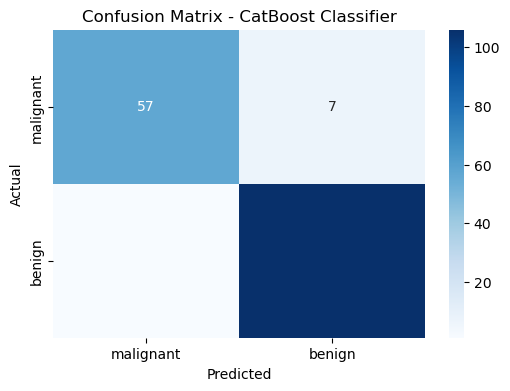

```python
from sklearn.datasets import load_breast_cancer
from sklearn.model_selection import train_test_split
from sklearn.metrics import confusion_matrix, accuracy_score
from catboost import CatBoostClassifier
import seaborn as sns
import matplotlib.pyplot as plt

# Load dataset
data = load_breast_cancer()
X, y = data.data, data.target

# Split dataset
X_train, X_test, y_train, y_test = train_test_split(
    X, y, test_size=0.3, random_state=42, stratify=y
)

# Train CatBoost Classifier (silent mode to suppress logs)
model = CatBoostClassifier(iterations=200, learning_rate=0.1, depth=6, verbose=0, random_state=42)
model.fit(X_train, y_train)

# Predictions
y_pred = model.predict(X_test)

# Accuracy
acc = accuracy_score(y_test, y_pred)
print(f"CatBoost Classifier Accuracy: {acc:.4f}")

# Confusion Matrix
cm = confusion_matrix(y_test, y_pred)

# Plot Confusion Matrix
plt.figure(figsize=(6,4))
sns.heatmap(cm, annot=True, fmt='d', cmap="Blues", xticklabels=data.target_names, yticklabels=data.target_names)
plt.xlabel("Predicted")
plt.ylabel("Actual")
plt.title("Confusion Matrix - CatBoost Classifier")
plt.show()
```

#### 10. You're working for a FinTech company trying to predict loan default using

customer demographics and transaction behavior. The dataset is imbalanced, contains missing values, and has both numeric and categorical features. Describe your step-by-step data science pipeline using boosting techniques: ● Data preprocessing & handling missing/categorical values ● Choice between AdaBoost, XGBoost, or CatBoost ● Hyperparameter tuning strategy ● Evaluation metrics you'd choose and why ● How the business would benefit from your model

Step 1: Data Preprocessing Handling Missing Values Numeric features: impute using median (robust to outliers) or more advanced methods (KNN imputation). Categorical features: impute with mode or add a category "Unknown". Boosting methods (esp. CatBoost) can handle missing values natively, reducing preprocessing effort. Handling Categorical Variables One-hot encoding for low-cardinality categorical features. Target encoding or CatBoost’s native categorical encoding for high-cardinality features (e.g., merchant IDs, occupation). Feature Scaling Tree-based boosting methods (XGBoost, CatBoost, AdaBoost) do not require feature scaling (unlike linear/logistic regression). Imbalanced Classes (Loan default is rare) Resampling: SMOTE (oversampling) or undersampling non-defaulters. Class weights: Use scale_pos_weight in XGBoost/LightGBM or class_weights in CatBoost. Threshold tuning: Adjust decision threshold to optimize recall/precision trade-off. Step 2: Choice of Boosting Algorithm AdaBoost Works with weak learners (usually decision stumps). Simpler but less effective for complex, high-dimensional, tabular data. XGBoost Strong performance on structured/tabular data. Can handle missing values, imbalanced data, and large datasets efficiently. CatBoost Best suited when many categorical variables are present. Handles categorical encoding and missing values internally. Less feature engineering required compared to XGBoost. 👉 Choice: If dataset has many categorical variables → CatBoost. If mostly numeric, but large and complex → XGBoost. AdaBoost would only be used as a baseline. Step 3: Hyperparameter Tuning Strategy Use GridSearchCV or RandomizedSearchCV with Stratified k-Fold Cross-Validation (to preserve class balance). Key hyperparameters: XGBoost / CatBoost learning_rate (controls shrinkage, smaller values = better generalization) n_estimators (number of trees) max_depth (tree depth, controls overfitting) subsample (row sampling) & colsample_bytree (feature sampling) scale_pos_weight (for imbalanced data) Regularization: L1/L2 penalties to prevent overfitting. Use early stopping (on validation set) to prevent unnecessary training. Step 4: Evaluation Metrics Since this is a loan default prediction problem: ROC-AUC: Good for overall ranking ability. Precision-Recall AUC: More important because defaults are rare (imbalanced). Recall (Sensitivity): Very important — missing a default means higher financial risk. Precision: Avoid too many false positives (rejecting too many good customers). Business Metric: Assign costs (false negatives = high loss, false positives = opportunity cost) and optimize using cost-sensitive learning. 👉 Primary metrics: PR-AUC + Recall (with threshold tuning). Step 5: Business Impact Reduce Credit Risk: Better default predictions = fewer risky loans issued. Maximize Profitability: Balance between rejecting risky borrowers and approving good ones. Fair Lending Decisions: Ensemble models like CatBoost/XGBoost improve stability and reduce bias from single models. Operational Efficiency: Automated decision-making speeds up loan approvals. Regulatory Compliance: Transparent model evaluation (feature importance, SHAP values) provides explainability for regulators. ✅ In summary: Preprocess with missing value handling + categorical encoding. Use CatBoost (if categorical-heavy) or XGBoost (if numeric-heavy). Tune hyperparameters with cross-validation & early stopping. Evaluate with PR-AUC, Recall, and cost-sensitive metrics. Business benefits: lower loan losses, fairer approvals, and faster decision-making.